# LoR Meta Report

## Data collected

Data used in this report are collected from ranked matches of Master players and players that faced master players in ranked.

All games are from the **EU** shard.

In total, **6324 matches** are collected, played between **June 28** and **July 3**.

### Region Playrate

This chart shows the percentage of decks running a specific region.

*The sum of all Regions’ Playrate should be close to 200% since almost every deck runs 2 regions.*

[figure not shown]

### Historical Playrate

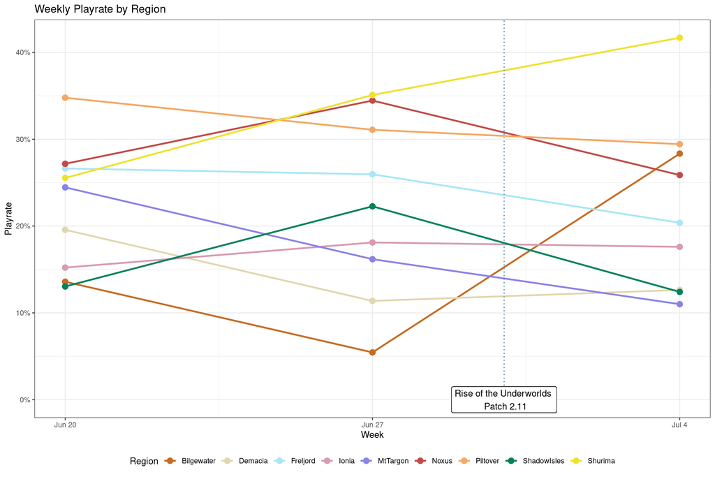

### Champion Playrate

This chart shows the percentage of decks running a specific champion.

*The sum of all Champions’ Playrate can be anything between 0% (if every deck is a champion-less deck) and 600% (if every deck is a 6-champions deck). Realistically, the real value will be ~200% since most decks run only 2 champions.*

[figure not shown]

### Archetypes Playrate

*At the moment, Archetypes are defined as combinatinos of champions and regions.*"

[figure not shown]

### Archetypes Winrate

[figure not shown]

### Matchup Table

The value shown in each cell is the winrate that the Champion Combination in the row has when playing against the Champion Combination in the column.

[figure not shown]

### Meta Score

*“Power ranking”* is defined in the “*Vicious Syndicate* way”; explanation taken from their website:

**Q: What is the meaning of the Power Rankings and how do you compute Power Ranking scores?**

*The Power Ranking scores are each deck’s weighted win rate against the field. We calculate a deck’s Power Ranking score by weighting its matchups against other archetypes, factoring each archetype’s frequency.*

This means that the Power ranking of a deck is not their observed winrate, but the winrate they should have according to their matchups winrate and the observed frequency of other region combinations.

*NB: if in the data collected there are no games between 2 specific champion combinations, I use 50% winrate as a default value in these calculations. Since here I am filtering the most played combinations, this should never happen; but just in case, I’m adding this as a disclaimer.* *Due to the small sample size, using Bayesian Averages might be a better option. I’ll think about it. In the meantime, I’m blaming Riot for the ridiculously low API rate limit.*

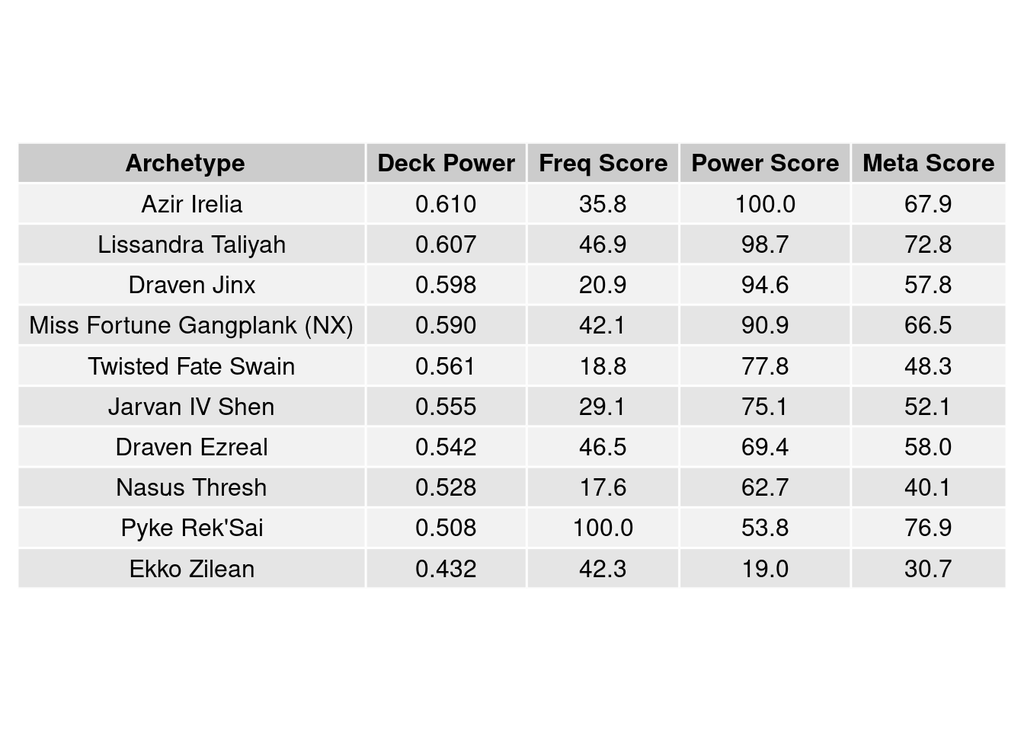

**Q: What is the meaning of the Meta Score and how do you compute it?**

*The Meta Score is a supplementary metric that measures each archetype’s relative standing in the meta, based on both win rate and prevalence, and in comparison to the theoretical “best deck”.*

- *We take the highest win rate recorded by a current archetype in a specific rank group, and set it to a fixed value of 100. We then determine the fixed value of 0 by deducting the highest win rate from 100%. For example, if the highest win rate recorded is 53%, a win rate of 47% will be set as the fixed value of 0. This is a deck’s Power Score. The range of 47% – 53%, whose power score ranges from 0 to 100, will contain “viable” decks. The length of this range will vary depending on the current state of the meta. Needless to say, it is possible for a deck to have a negative power score, but it can never have a power score that exceeds 100.*
- *We take the highest frequency recorded by a current archetype in a specific rank group, and set it to a fixed value of 100. The fixed value of 0 will then always be 0% popularity. This is a deck’s Frequency Score. A deck’s frequency score cannot be a negative number.*
- *We calculate the simple average of a deck’s Power Score and Frequency Score to find its vS Meta Score. The vS Meta Score is a deck’s relative distance to the hypothetical strongest deck in the game. Think of Power Score and Frequency Score as the coordinates (x, y) of a deck within a Scatter Plot. The Meta Score represents its relative placement in the plane between the fixed values of (0, 0) and (100,100).*
- *If a deck records both the highest popularity and the highest win rate, its Meta Score will be 100. It will be, undoubtedly, the best deck in the game.*

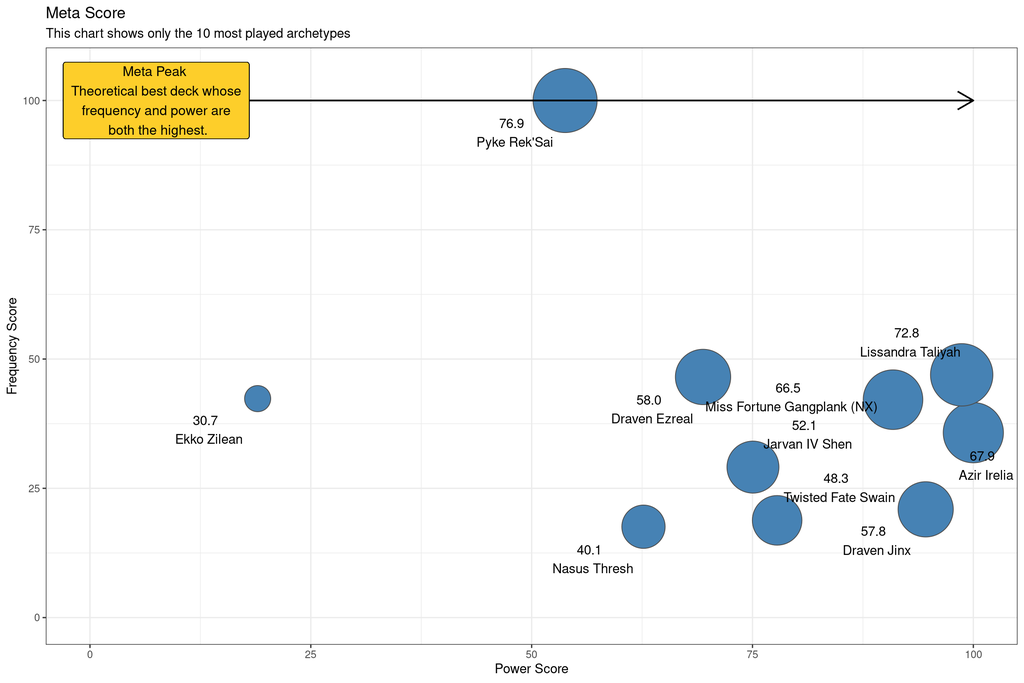